# SDS 4030 - Statistics for Data Science II: Final Project

Main Markdown File

Noah Calabrese, Natalia Jamula, Tim Mellman

Preliminary library loading, reading code in, and exploratory data analysis

```r
gss = read.table("gss.txt", header = TRUE)
summary(gss)
```

```
##       Age             Educ           Hours           Sex
##  Min.   :18.00   Min.   : 4.00   Min.   : 3.00   Length:815
##  1st Qu.:32.00   1st Qu.:12.00   1st Qu.:39.00   Class :character
##  Median :42.00   Median :14.00   Median :40.00   Mode  :character
##  Mean   :42.91   Mean   :13.93   Mean   :42.59
##  3rd Qu.:52.00   3rd Qu.:16.00   3rd Qu.:50.00
##  Max.   :88.00   Max.   :20.00   Max.   :89.00
##     TVHours          Happy               MEduc           FEduc
##  Min.   : 0.000   Length:815         Min.   : 0.00   Min.   : 0.00
##  1st Qu.: 2.000   Class :character   1st Qu.:10.00   1st Qu.: 9.00
##  Median : 2.000   Mode  :character   Median :12.00   Median :12.00
##  Mean   : 2.709                      Mean   :11.61   Mean   :11.45
##  3rd Qu.: 3.000                      3rd Qu.:14.00   3rd Qu.:14.00
##  Max.   :20.000                      Max.   :20.00   Max.   :20.00
##    Marital               Sibs            Work              Zodiac
##  Length:815         Min.   : 0.000   Length:815         Length:815
##  Class :character   1st Qu.: 2.000   Class :character   Class :character
##  Mode  :character   Median : 3.000   Mode  :character   Mode  :character
##                     Mean   : 3.439
##                     3rd Qu.: 5.000
##                     Max.   :16.000
##      Income
##  Min.   :     500
##  1st Qu.:   23750
##  Median :   45000
##  Mean   :  324767
##  3rd Qu.:   67500
##  Max.   :28637626
```

We begin our data science workflow by familiarizing ourselves with the GSS dataset. The dataset contains 815 rows corresponding to 815 individuals’ survery responses. The dataset contains 13 variables. There are 8 discrete numerical variables: Age (Responder’s Age), Educ (Total years of education), Hours (Weekly work hours), TVHours (Hours spent watching TV daily), MEduc (Mother’s years of education), FEduc (Father’s years of education), Sibs (Number of siblings), and Income (Yearly income). Thus there are 5 categorical variables: Sex (Responder’s sex), Happy (Happiness level), Marital (Marital status), Work (Work status), and Zodiac (Zodiac sign). Uniquely they take on the following values: Sex (Female, Male), Happy (Pretty Happy, Very Happy, Not Too Happy), Marital (“Divorced, Widowed, Married, Never Married, Separated), Work (Fulltime, Housekeeping, Laid Off, School, Retired, Parttime, Not Working, Other), and Zodiac (Virgo, Libra, Taurus, Pisces, Cancer, Aquarius, Leo, Capricorn, Aries, Gemini, Sagittarius, Scorpio).

Now that we understand our data we isolate our goal being to build a linear model for the response variable yearly income by treating all other seven quanitative variables as covariates and ignoring all five qualitative variables.

Step 1:

1. Fit a multiple linear model with all available quantitative covariates.
2. Perform exact and asymptotic tests for the set of linear constraints which has been specified for your team.
3. Do all of your conclusions agree with each other and what are the relationships between the different tests?

## i) Fitting a multiple linear model with all available quantitative covariates. This is the model that we will use for the next few parts of this project

```r
library(faraway)
full_model <- lm(Income ~ Age + Educ + Hours + TVHours + MEduc + FEduc +
    Sibs, gss)
summary(full_model)
```

```
##
## Call:
## lm(formula = Income ~ Age + Educ + Hours + TVHours + MEduc +
##     FEduc + Sibs, data = gss)
##
## Residuals:
##      Min       1Q   Median       3Q      Max
## -1211280  -410167  -271382  -129856 28149890
##
## Coefficients:
##             Estimate Std. Error t value Pr(>|t|)
## (Intercept)   211943     688636   0.308   0.7583
## Age             2949       6231   0.473   0.6361
## Educ           20448      35626   0.574   0.5661
## Hours          -9324       5923  -1.574   0.1159
## TVHours       -65363      42493  -1.538   0.1244
## MEduc          -3715      32699  -0.114   0.9096
## FEduc          10206      28724   0.355   0.7225
## Sibs           58649      33490   1.751   0.0803 .
## ---
## Signif. codes:  0 '***' 0.001 '**' 0.01 '*' 0.05 '.' 0.1 ' ' 1
##
## Residual standard error: 2340000 on 807 degrees of freedom
## Multiple R-squared:  0.0101, Adjusted R-squared:  0.001516
## F-statistic: 1.177 on 7 and 807 DF,  p-value: 0.3136
```

For the sake of later model comparison we will find the least squares estimate of the coefficient vector, an unbiased estimate of the residual variance and the MLE of the residual variance in the full model.

```r
Y = gss$Income
X = model.matrix(full_model)
n = dim(X)[1]
p = dim(X)[2]
beta = solve(crossprod(X), crossprod(X, Y))[, ]
print(beta)
```

```
## (Intercept)         Age        Educ       Hours     TVHours       MEduc
##  211942.841    2949.415   20448.463   -9323.480  -65363.112   -3715.210
##       FEduc        Sibs
##   10205.481   58648.969
```

```r
residuals = Y - X %*% beta
sigma = sqrt(mean(residuals^2))
print(sigma^2)
```

```
## [1] 5.42076e+12
```

```r
S = sqrt(sum(residuals^2)/(n - p))
print(S^2)
```

```
## [1] 5.474497e+12
```

The reduced model is a little more tricky where we have to create a model in which it follows the constraints given by: $H_0 : 10 * \beta_{MEduc} = 20 * \beta_{FEduc} = 2$.

We can rewrite the constraint as $10 * \beta_{MEduc} = 2$ , $20 * \beta_{FEduc} = 2$. Or, $\beta_{MEduc} = 0.2$, $\beta_{FEduc} = 0.1$

We can plug the null values into the full model, replacing coefficients with the constants so the full model becomes $Y_i = \beta_0 +\beta_{Age}{\text{Age}_i} +\beta_{Educ}{\text{Educ}_i} +\beta_{Hours}{\text{Hours}_i} + \beta_{TVHours}{\text{TVHours}_i} + 0.2*{\text{MEduc}_i} + 0.1*{\text{FEduc}_i} + \beta_{Sibs}{\text{Sibs}_i} + \epsilon_i$

We have to set MEduc and FEduc, the fixed parts of the response in the reduced model, as the offset.

```r
reduced_model <- lm(Income ~ Age + Educ + Hours + TVHours + Sibs, gss,
    offset = 0.2 * MEduc + 0.1 * FEduc)
summary(reduced_model)
```

```
##
## Call:
## lm(formula = Income ~ Age + Educ + Hours + TVHours + Sibs, data = gss,
##     offset = 0.2 * MEduc + 0.1 * FEduc)
##
## Residuals:
##      Min       1Q   Median       3Q      Max
## -1208997  -397497  -267841  -139546 28119340
##
## Coefficients:
##             Estimate Std. Error t value Pr(>|t|)
## (Intercept)   286038     616017   0.464   0.6425
## Age             2334       5805   0.402   0.6878
## Educ           23374      33141   0.705   0.4808
## Hours          -9411       5911  -1.592   0.1117
## TVHours       -66218      42346  -1.564   0.1183
## Sibs           56138      32385   1.733   0.0834 .
## ---
## Signif. codes:  0 '***' 0.001 '**' 0.01 '*' 0.05 '.' 0.1 ' ' 1
##
## Residual standard error: 2337000 on 809 degrees of freedom
## Multiple R-squared:  0.009939,   Adjusted R-squared:  0.00382
## F-statistic: 1.624 on 5 and 809 DF,  p-value: 0.151
```

```r
R <- rbind(c(0, 0, 0, 0, 0, 1, 0, 0), c(0, 0, 0, 0, 0, 0, 1, 0))  ##the 1's in R represent the MEduc and FEduc since those are within the null hypothesis
r <- c(0.2, 0.1)
k <- length(r)
beta0 = beta - solve(crossprod(X), crossprod(R, solve(R %*% solve(crossprod(X),
    t(R)), R %*% beta - r)))[, ]
print(beta0)
```

```
## (Intercept)         Age        Educ       Hours     TVHours       MEduc
##  286037.934    2333.632   23374.285   -9411.360  -66218.159       0.200
##       FEduc        Sibs
##       0.100   56138.450
```

```r
residuals0 = Y - X %*% beta0
sigma0 = sqrt(mean(residuals0^2))
print(sigma0^2)
```

```
## [1] 5.421657e+12
```

```r
S0 = sqrt(sum(residuals0^2)/(n - p + k))
print(S0^2)
```

```
## [1] 5.461868e+12
```

## ii) Perform exact and asymptotic tests for the set of linear constraints which has been specified for your team.

We have to test the hypothesis $H_0 : 10 * \beta_{MEduc} = 20 * \beta_{FEduc} = 2$ against exact and asymptotic tests. The best exact test is, of course, the exact F-test assuming we are have normalcy conditions (which we will check later, but step 1 ensures that we do it regardless of the normalcy checks). To test for the asymptotic tests it is logical to use the Wald test since we have a large sample (n = 815). It is also one of the easier asymptotic tests to check, so we will use it due to its efficiency, accuracy, and sample size.

### Exact F- Test

```r
FT = crossprod(R %*% beta - r, solve(R %*% solve(crossprod(X), t(R)),
    R %*% beta - r))[, ]/(k * S^2)
print(FT)
```

```
## [1] 0.06680263
```

```r
pvalue = pf(FT, k, n - p, lower.tail = FALSE)
print(pvalue)
```

```
## [1] 0.935385
```

```r
anova(reduced_model, full_model)
```

|  | Res.Df | RSS | Df | Sum of Sq | F | Pr(>F) |
| --- | --- | --- | --- | --- | --- | --- |
| 1 | 809 | 4.418651e+15 | NA | NA | NA | NA |
| 2 | 807 | 4.417919e+15 | 2 | 731421625522 | 0.06680263 | 0.935385 |

The observed value of the F test statistic is equal to 0.06680263 and the corresponding p-value is equal to 0.935385, so we fail to reject the null hypothesis at significance level $\alpha$ = 5%.

### Wald Test

```r
WT = crossprod(R %*% beta - r, solve(R %*% solve(crossprod(X), t(R)),
    R %*% beta - r))[, ]/S^2
print(WT)
```

```
## [1] 0.1336053
```

```r
pvalue = pchisq(WT, k, lower.tail = FALSE)
print(pvalue)
```

```
## [1] 0.9353798
```

```r
anova(reduced_model, full_model, test = "Chisq")
```

|  | Res.Df | RSS | Df | Sum of Sq | Pr(>Chi) |
| --- | --- | --- | --- | --- | --- |
| 1 | 809 | 4.418651e+15 | NA | NA | NA |
| 2 | 807 | 4.417919e+15 | 2 | 731421625522 | 0.9353798 |

The observed value of the Wald test statistic is equal to 0.1336053 and the corresponding p-value is equal to 0.9353798, so we fail to reject the null hypothesis at significance level $\alpha$ = 5%

### Score Test

```r
SF = crossprod(X, residuals0)/sigma0^2
FI = crossprod(X)/sigma0^2
ST = crossprod(SF, solve(FI, SF))[, ]
print(ST)
```

```
## [1] 0.1349074
```

```r
P = X %*% solve(crossprod(X), t(X))
ST = sum((P %*% residuals0)^2)/sigma0^2
print(ST)
```

```
## [1] 0.1349074
```

```r
pvalue = pchisq(ST, k, lower.tail = FALSE)
print(pvalue)
```

```
## [1] 0.934771
```

The observed value of the Score test statistic is equal to 0.1349074 and the corresponding p-value is equal to 0.934771, so we fail to reject the null hypothesis at significance level $\alpha$ = 5%.

### Likelihood Ratio Test

```r
LR = -2 * (logLik(reduced_model)[1] - logLik(full_model)[1])
print(LR)
```

```
## [1] 0.1349186
```

```r
LR = n * log(sigma0^2/sigma^2)
print(LR)
```

```
## [1] 0.1349186
```

```r
pchisq(LR, k, lower.tail = FALSE)
```

```
## [1] 0.9347658
```

```r
library(lmtest)
lrtest(reduced_model, full_model)
```

|  | #Df | LogLik | Df | Chisq | Pr(>Chisq) |
| --- | --- | --- | --- | --- | --- |
| 1 | 7 | -13104.91 | NA | NA | NA |
| 2 | 9 | -13104.85 | 2 | 0.1349186 | 0.9347658 |

The observed value of the Likelihood Ratio test statistic is equal to 0.1349186 and the corresponding p-value is equal to 0.9347658, so we fail to reject the null hypothesis at significance level $\alpha$ = 5%.

## iii) Do all of your conclusions agree with each other and what are the relationships between the different tests?

Yes, all of my conclusions agree with each other as in the exact F test, Wald test, score test, and likelihood ratio test we have failed to reject the null, and they all yield similar p-values. Both the F-Exact test and asymptotic tests provide very small test statistics which means we do not have substantial evidence to reject the null hypothesis.

```r
WT = k * FT
print(WT)
```

```
## [1] 0.1336053
```

```r
ST = WT * S^2/sigma0^2
print(ST)
```

```
## [1] 0.1349074
```

```r
LR = n * log(n/(n - p) * WT/ST)
print(LR)
```

```
## [1] 0.1349186
```

```r
LR = n * log(1 + WT/(n - p))
print(LR)
```

```
## [1] 0.1349186
```

```r
LR = -n * log(1 - ST/n)
print(LR)
```

```
## [1] 0.1349186
```

In the F test, the exact F-statistic is 0.06680263, and the p-value is 0.935385. In the Wald test the Wald statistic is 0.1336053 and the p-value is 0.9353798. According to Slutsky’s theorem, we infer that $W_n$ = kF, the Wald statistic equals kF asymptotically. The Wald statistic is k times the 0.06680263 where k=2. While the F test relies on a finite sample, the Wald statistic follows a chi-square distribution and asymptotic approximations.

In the score test, the score test statistic is 0.1349074 and the p-value is 0.934771 We know that $\hat{\sigma}_0^2 ST = S^2 W_n$. The Wald and Score test statistics only differ in terms of the residual variance estimation. The Wald test statistic utilizes an unbiased estimator of the residual variance under the full model while the Score test statistic utilizes the MLE of the residual variance under the reduced model. In other words the Wald test uses the full model variance and the Score test uses reduced model variance. Thus we can see how the two test statistics differ slightly.

In the likelihood ratio test, likelihood test statistic is 0.1349186 and the p-value is 0.9347658. Below we see how the Likelihood test statistic relates to the Wald test and Score test through transformations, implying they provide the same inference for very large sample sizes.

So yes, we observe that the results of all the four test statistics concur. The results of the asymptotic Wald, Likelihood Ratio and Score tests are perfectly in line with the results of the exact F test, which is expected since n = 815 which is large enough to be accurate for an asymptotic test. All three asymptotic tests, Wald, Score & Likelihood Ratio Tests, are all asymptotically equivalent, converging to the same test statistics and giving us the same conclusions. They measure deviation from the null differently, where the Wald test measures the horizontal differences of the parameters and the null, the Score test measures the slope of the log likelihood at the null, and the likelihood ratio test measures the vertical differences in log likelihood.

Step 2:

1. Is the variance of the random error terms non-constant as a function of any of the quantitative or qualitative covariates?
2. Perform suitable heteroscedasticity tests and state your conclusions.

## i) Is the variance of the random error terms non-constant as a function of any of the quantitative or qualitative covariates?

We begin by plotting and examining a residuals vs fitted plot of the full model (shown in part 1). We can note that the residuals increase as the fitted values increases and also has some extreme outliers and leverage points (also called influential outliers). The points are basically pulling the regression line and likely causing that massive variance, or at least factoring into the magnitude of it. Thus, overall, there is evidence of non constant variance since the spread of residuals appears to increase for larger fitted values.

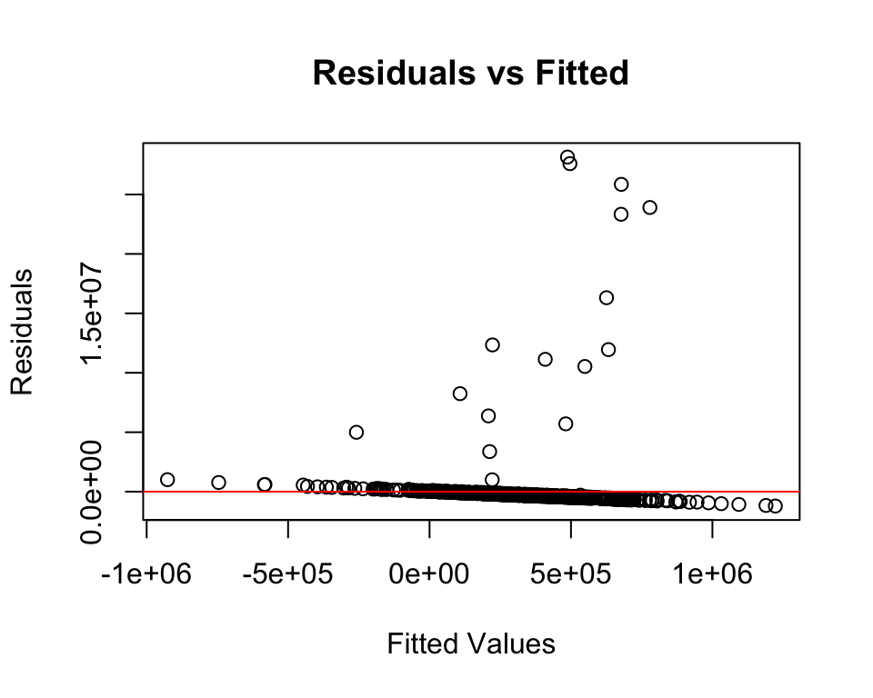

```r
library(faraway)
full_model <- lm(Income ~ Age + Educ + Hours + TVHours + MEduc + FEduc +
    Sibs, data = gss)
Y = gss$Income
X = model.matrix(full_model)
n = dim(X)[1]
p = dim(X)[2] - 1
residuals = full_model$residuals
plot(fitted(full_model), residuals, xlab = "Fitted Values", ylab = "Residuals",
    main = "Residuals vs Fitted")
abline(h = 0, col = "red")
```

## Quantitative Covariates

### Responder’s age

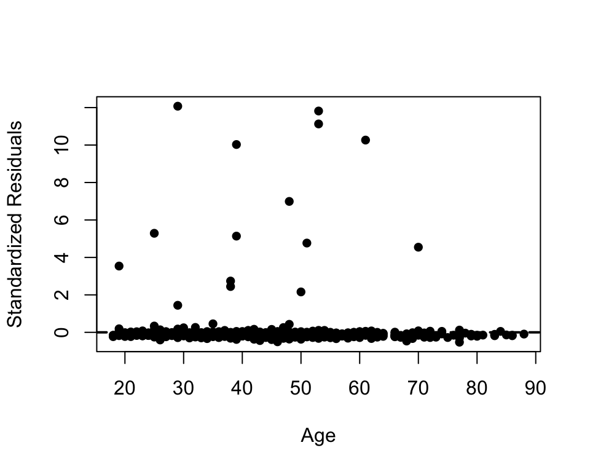

```r
plot(rstandard(full_model) ~ Age, data = gss, ylab = "Standardized Residuals",
    xlab = "Age", pch = 16)
abline(h = 0, lty = 2, lwd = 2)
```

### Total years of education

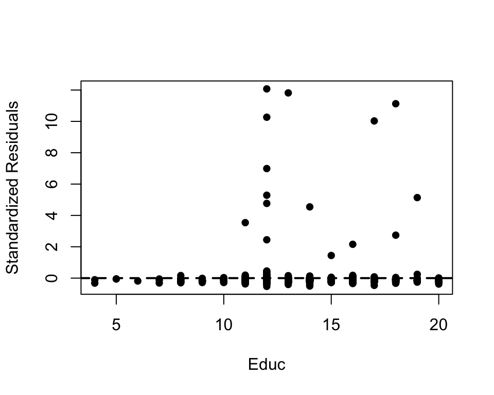

```r
plot(rstandard(full_model) ~ Educ, data = gss, ylab = "Standardized Residuals",
    xlab = "Educ", pch = 16)
abline(h = 0, lty = 2, lwd = 2)
```

### Weekly work hours

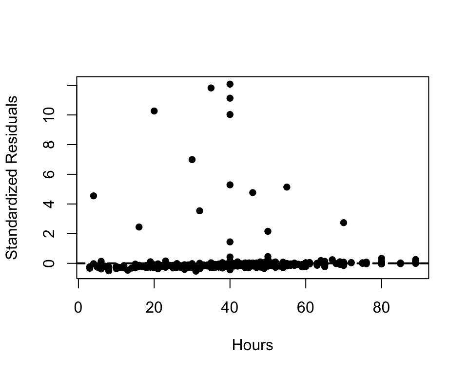

```r
plot(rstandard(full_model) ~ Hours, data = gss, ylab = "Standardized Residuals",
    xlab = "Hours", pch = 16)
abline(h = 0, lty = 2, lwd = 2)
```

### Hours spent watching TV daily

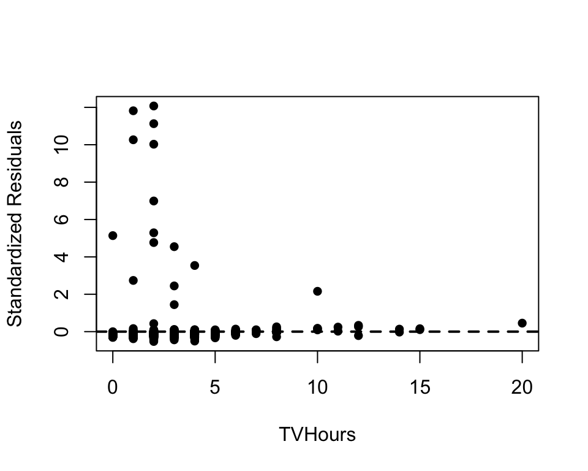

```r
plot(rstandard(full_model) ~ TVHours, data = gss, ylab = "Standardized Residuals",
    xlab = "TVHours", pch = 16)
abline(h = 0, lty = 2, lwd = 2)
```

### Mother’s years of education

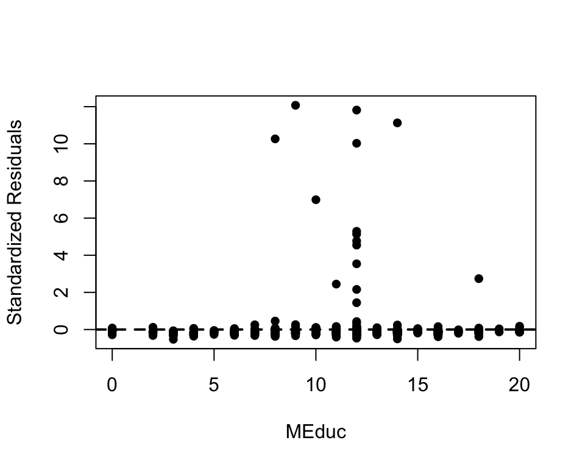

```r
plot(rstandard(full_model) ~ MEduc, data = gss, ylab = "Standardized Residuals",
    xlab = "MEduc", pch = 16)
abline(h = 0, lty = 2, lwd = 2)
```

### Father’s years of education

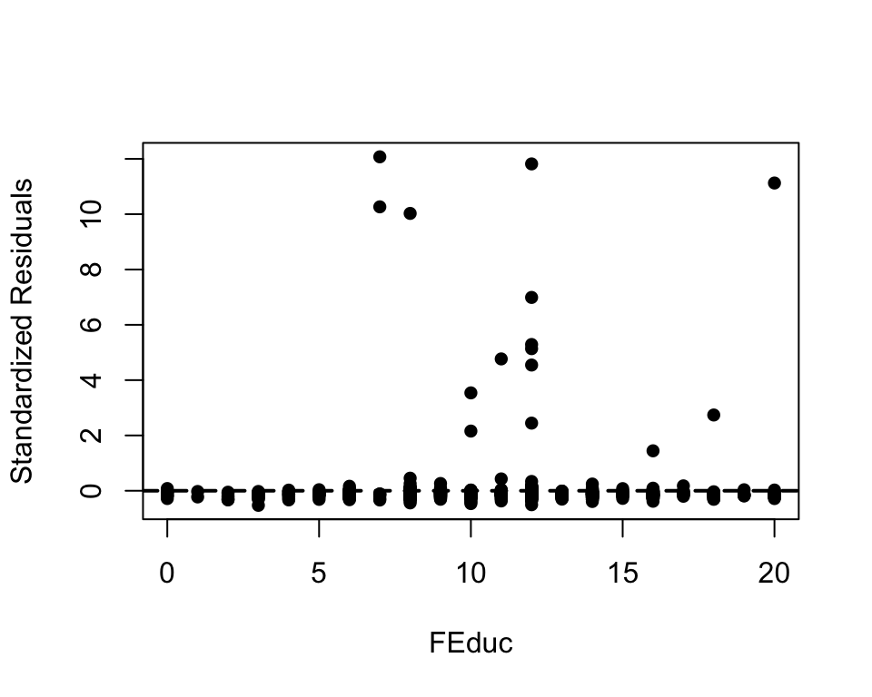

```r
plot(rstandard(full_model) ~ FEduc, data = gss, ylab = "Standardized Residuals",
    xlab = "FEduc", pch = 16)
abline(h = 0, lty = 2, lwd = 2)
```

### Number of siblings

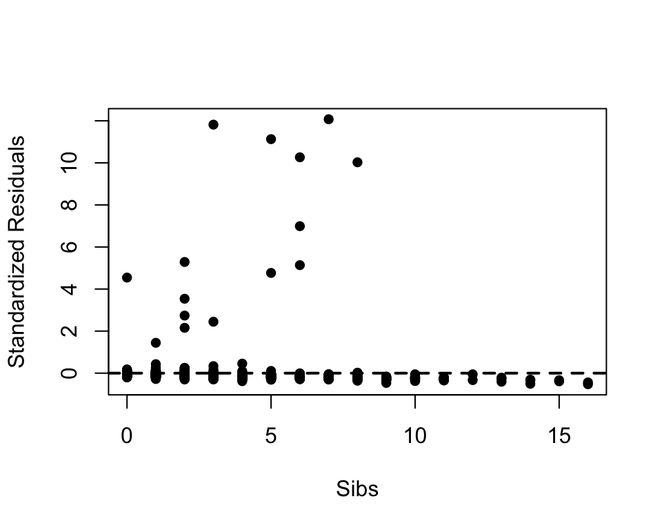

```r
plot(rstandard(full_model) ~ Sibs, data = gss, ylab = "Standardized Residuals",
    xlab = "Sibs", pch = 16)
abline(h = 0, lty = 2, lwd = 2)
```

After inspecting the standardized residuals plotted against each quantitative covariate, I noticed the presence of extreme outliers but no systematic pattern of increasing or decreasing spread as a function of a quantitative covariate that would indicate the form of heteroscedasticity that appears when the variance of the random error terms is a function of some of the available covariates.

## Qualitative Covariates

### Responder’s sex

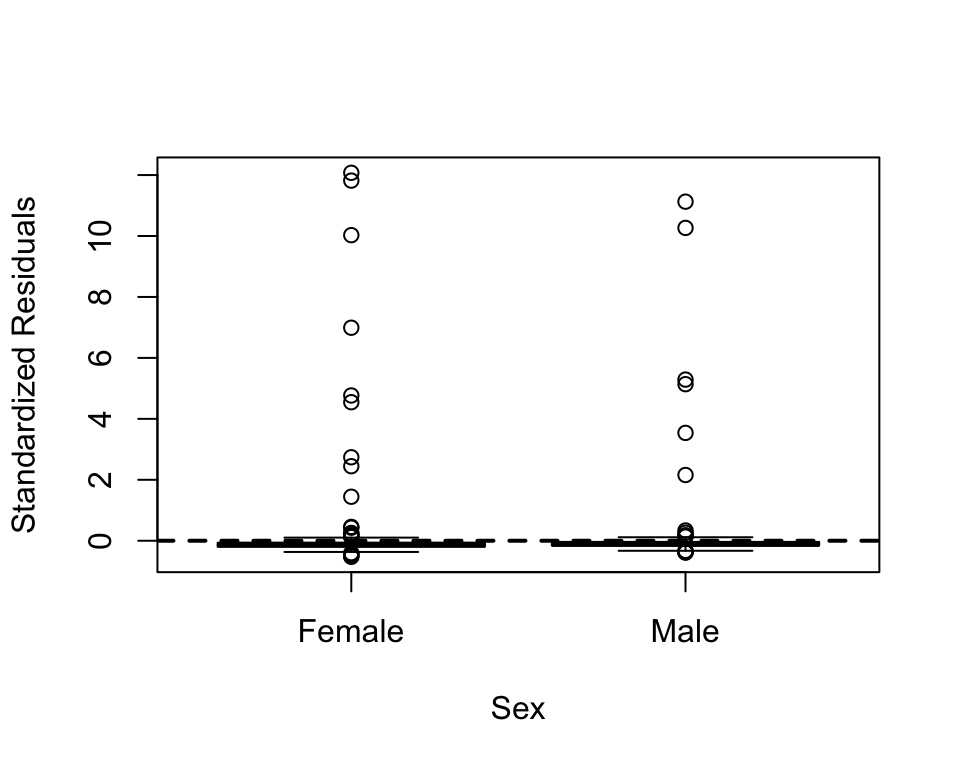

```r
boxplot(rstandard(full_model) ~ Sex, data = gss, ylab = "Standardized Residuals",
    xlab = "Sex")
abline(h = 0, lty = 2, lwd = 2)
```

### Happiness level

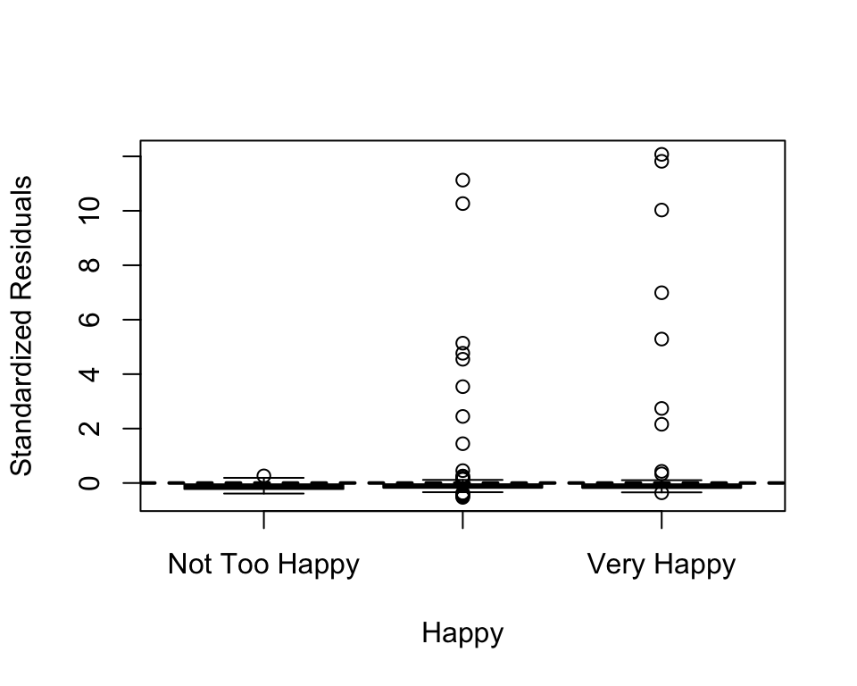

```r
boxplot(rstandard(full_model) ~ Happy, data = gss, ylab = "Standardized Residuals",
    xlab = "Happy")
abline(h = 0, lty = 2, lwd = 2)
```

### Marital status

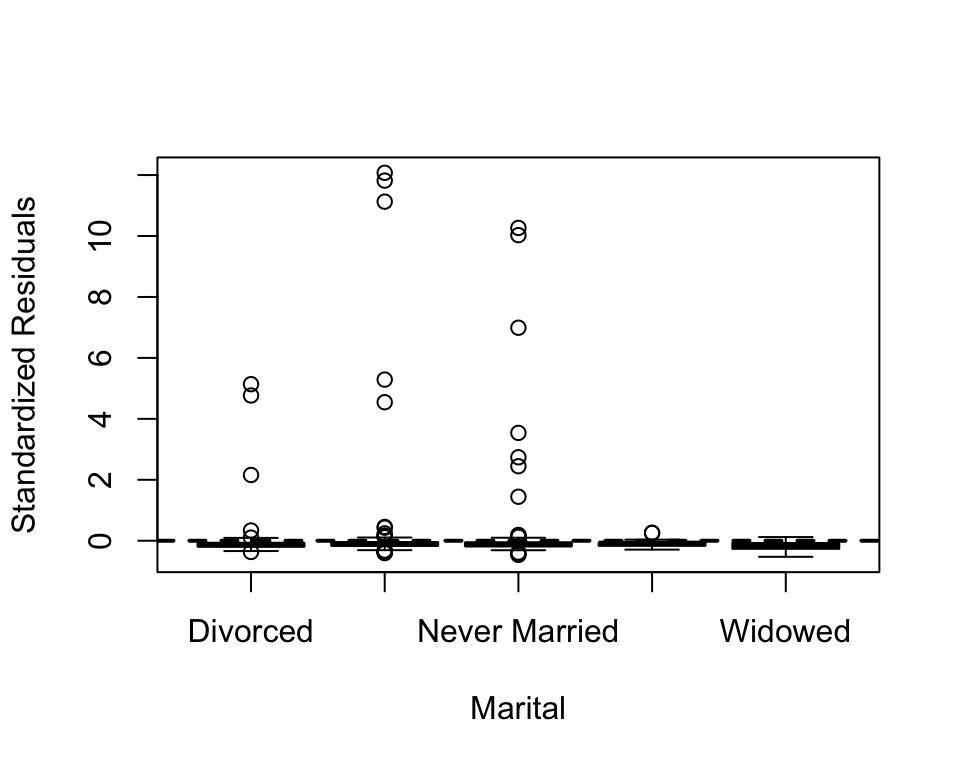

```r
boxplot(rstandard(full_model) ~ Marital, data = gss, ylab = "Standardized Residuals",
    xlab = "Marital")
abline(h = 0, lty = 2, lwd = 2)
```

### Work status

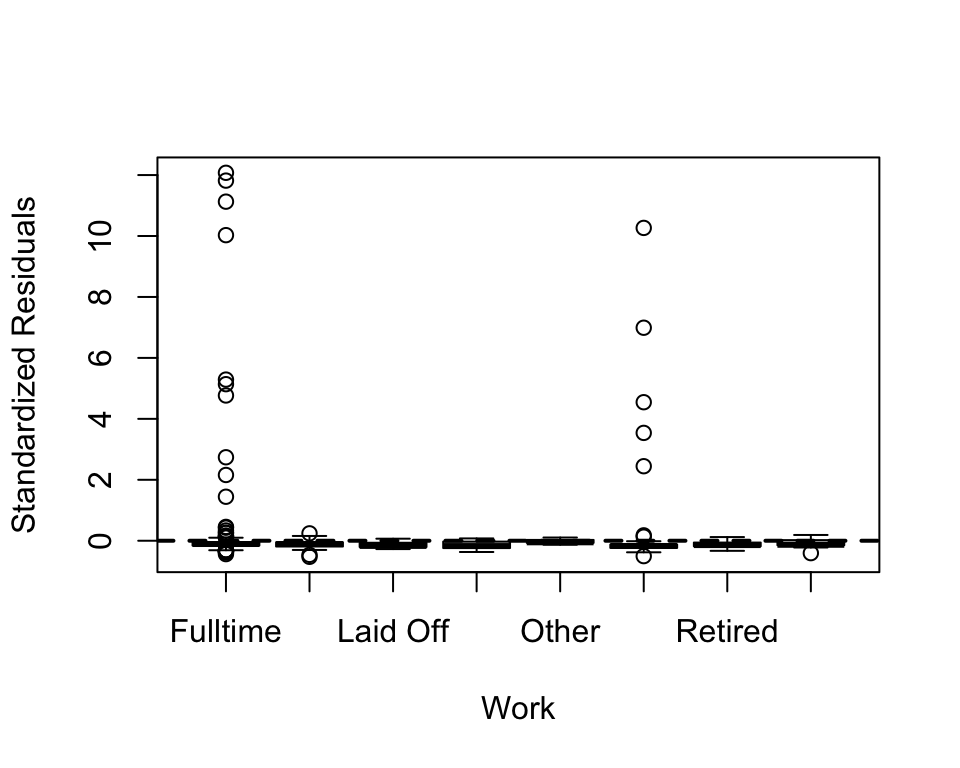

```r
boxplot(rstandard(full_model) ~ Work, data = gss, ylab = "Standardized Residuals",
    xlab = "Work")
abline(h = 0, lty = 2, lwd = 2)
```

### Zodiac sign

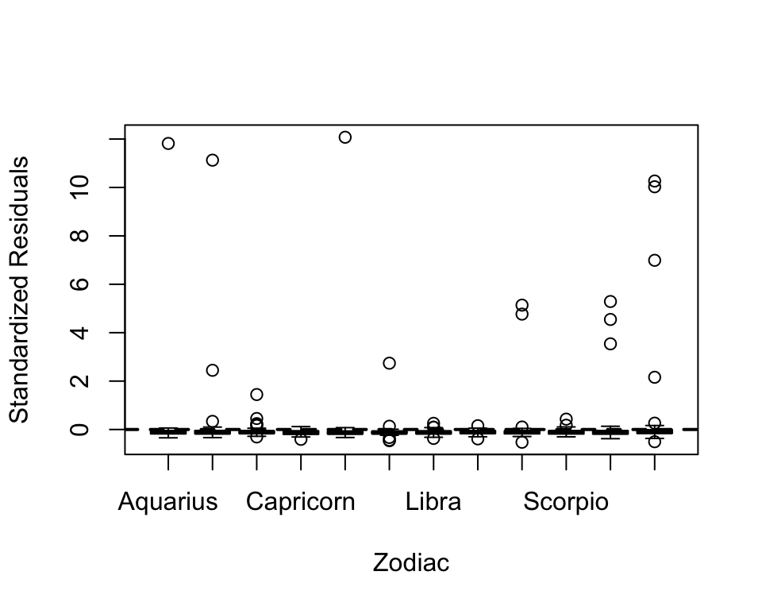

```r
boxplot(rstandard(full_model) ~ Zodiac, data = gss, ylab = "Standardized Residuals",
    xlab = "Zodiac")
abline(h = 0, lty = 2, lwd = 2)
```

After inspecting the standardized residuals plotted against each qualititative covariate, I again noticed the presence of extreme outliers but no pattern of difference in spread for the boxplots across the levels of the qualitative covariate that would indicate the form of heteroscedasticity that appears when the variance of the random error terms differs across the different levels of some qualitative covariate.

So while we see visual indications for the violation of homoscedasticity in the residuals vs fitted plot, the pattern is less clear when the standardized residuals are plotted against individual quantitative and qualitative covariates.

## ii) Perform suitable heteroscedasticity tests and state your conclusions.

We use the Breush-Pagan test for heteroscedasticity to test whether the variance of the error terms is a linear function of the covariates. The BP test statistic is 8.955868 and p-value is 0.2558401. Thus, we can not reject the null hypothesis that the full_model is homoscedastic since the p-value is larger than the alpha threshold of 0.05. This means we do not have sufficient evidence to reject the null hypothesis of homoskedasticity at $\alpha$ = 5% and we do not detect a relationship of linear dependence of variance on the covariates.

```r
# Breusch-Pagan Test for heteroscedasticity
Y = gss$Income
residuals = full_model$residuals
Yaux = residuals^2
aux = lm(Yaux ~ Age + Educ + Hours + TVHours + MEduc + FEduc + Sibs,
    data = gss)
BP = n * summary(aux)$r.squared
print(BP)
```

```
## [1] 8.955868
```

```r
pvalue = pchisq(BP, p, lower.tail = FALSE)
print(pvalue)
```

```
## [1] 0.2558401
```

```r
library(lmtest)
bptest(full_model)
```

```
##
##  studentized Breusch-Pagan test
##
## data:  full_model
## BP = 8.9559, df = 7, p-value = 0.2558
```

We can also use the Brown-Forsythe Test to test for heteroscedasticity-

Brown-Forsythe for Sex:

Grouping by sex, since we need to group by a categorical variable with levels (sex has 2 levels so it’s valid). So, for sex the Brown-Forscythe test shows that there is np sufficient evidence that it is heteroscadastic since the p-value is 0.6143.

```r
gss$Sex <- as.factor(gss$Sex)
fit = lm(Income ~ Age + Educ + Hours + TVHours + MEduc + FEduc + Sibs,
    data = gss)
Ymed = aggregate(Income ~ Sex, data = gss, median)[gss$Sex, 2]
Yaux = abs(gss$Income - Ymed)
aux = lm(Yaux ~ Sex, data = gss)
anova(aux)
```

|  | Df | Sum Sq | Mean Sq | F value | Pr(>F) |
| --- | --- | --- | --- | --- | --- |
| Sex | 1 | 1.392250e+12 | 1.392250e+12 | 0.2541706 | 0.6142902 |
| Residuals | 813 | 4.453307e+15 | 5.477622e+12 | NA | NA |

```r
library(car)
leveneTest(Income ~ Sex, data = gss)
```

|  | Df | F value | Pr(>F) |
| --- | --- | --- | --- |
| group | 1 | 0.2541706 | 0.6142902 |
|  | 813 | NA | NA |

Brown-Forsythe for Work: Grouping by work, since we need to group by a categorical variable that has levels (Work has 2+). So, for work the Brown-Forscythe test shows that there is no sufficient evidence that it is heteroscadastic since the p-value is 0.6582.

```r
gss$Work <- as.factor(gss$Work)
fit = lm(Income ~ Age + Educ + Hours + TVHours + MEduc + FEduc + Sibs,
    data = gss)
Ymed = aggregate(Income ~ Work, data = gss, median)[gss$Work, 2]
Yaux = abs(gss$Income - Ymed)
aux = lm(Yaux ~ Work, data = gss)
anova(aux)
```

|  | Df | Sum Sq | Mean Sq | F value | Pr(>F) |
| --- | --- | --- | --- | --- | --- |
| Work | 7 | 2.750779e+13 | 3.929684e+12 | 0.7163146 | 0.6582361 |
| Residuals | 807 | 4.427182e+15 | 5.485975e+12 | NA | NA |

```r
library(car)
leveneTest(Income ~ Work, data = gss)
```

|  | Df | F value | Pr(>F) |
| --- | --- | --- | --- |
| group | 7 | 0.7163146 | 0.6582361 |
|  | 807 | NA | NA |

Brown-Forsythe for Marital: Grouping by Marital, since we need to group by a categorical variable that has levels (Marital has 2+). So, for work the Brown-Forscythe test shows that there is no sufficient evidence that it is heteroscadastic since the p-value is 0.7978.

```r
gss$Marital <- as.factor(gss$Marital)
fit = lm(Income ~ Age + Educ + Hours + TVHours + MEduc + FEduc + Sibs,
    data = gss)
Ymed = aggregate(Income ~ Marital, data = gss, median)[gss$Marital, 2]
Yaux = abs(gss$Income - Ymed)
aux = lm(Yaux ~ Marital, data = gss)
anova(aux)
```

|  | Df | Sum Sq | Mean Sq | F value | Pr(>F) |
| --- | --- | --- | --- | --- | --- |
| Marital | 4 | 9.116024e+12 | 2.279006e+12 | 0.415182 | 0.7977758 |
| Residuals | 810 | 4.446231e+15 | 5.489174e+12 | NA | NA |

```r
library(car)
leveneTest(Income ~ Marital, data = gss)
```

|  | Df | F value | Pr(>F) |
| --- | --- | --- | --- |
| group | 4 | 0.415182 | 0.7977758 |
|  | 810 | NA | NA |

Brown-Forsythe for Zodiac: Grouping by Zodiac, since we need to group by a categorical variable that has levels (Zodiac has 2+). So, for work the Brown-Forscythe test shows that there is no sufficient evidence that it is heteroscadastic since the p-value is 0.2985

```r
gss$Zodiac <- as.factor(gss$Zodiac)
fit = lm(Income ~ Age + Educ + Hours + TVHours + MEduc + FEduc + Sibs,
    data = gss)
Ymed = aggregate(Income ~ Zodiac, data = gss, median)[gss$Zodiac, 2]
Yaux = abs(gss$Income - Ymed)
aux = lm(Yaux ~ Zodiac, data = gss)
anova(aux)
```

|  | Df | Sum Sq | Mean Sq | F value | Pr(>F) |
| --- | --- | --- | --- | --- | --- |
| Zodiac | 11 | 7.069868e+13 | 6.427153e+12 | 1.17756 | 0.2984799 |
| Residuals | 803 | 4.382796e+15 | 5.458028e+12 | NA | NA |

```r
library(car)
leveneTest(Income ~ Zodiac, data = gss)
```

|  | Df | F value | Pr(>F) |
| --- | --- | --- | --- |
| group | 11 | 1.17756 | 0.2984799 |
|  | 803 | NA | NA |

Brown-Forsythe for Happy: Grouping by Happy, since we need to group by a categorical variable that has levels (Happy has 2+). So, for work the Brown-Forscythe test shows that there is no sufficient evidence that it is heteroscadastic since the p-value is 0.2187

```r
gss$Happy <- as.factor(gss$Happy)
fit = lm(Income ~ Age + Educ + Hours + TVHours + MEduc + FEduc + Sibs,
    data = gss)
Ymed = aggregate(Income ~ Happy, data = gss, median)[gss$Happy, 2]
Yaux = abs(gss$Income - Ymed)
aux = lm(Yaux ~ Happy, data = gss)
anova(aux)
```

|  | Df | Sum Sq | Mean Sq | F value | Pr(>F) |
| --- | --- | --- | --- | --- | --- |
| Happy | 2 | 1.664520e+13 | 8.322602e+12 | 1.523102 | 0.2186566 |
| Residuals | 812 | 4.436965e+15 | 5.464243e+12 | NA | NA |

```r
library(car)
leveneTest(Income ~ Happy, data = gss)
```

|  | Df | F value | Pr(>F) |
| --- | --- | --- | --- |
| group | 2 | 1.523102 | 0.2186566 |
|  | 812 | NA | NA |

Step 3:

1. Calculate a suitable heteroscedasticity-consistent estimate for the covariance matrix of the regression coefficients. How does it compare against the corresponding ordinary least squares estimate?
2. Calculate heteroscedasticity-consistent t-test statistics and 95 percent CIs for the regression coefficients. How do they compare against the results yielded by the ordinary least squares method?

```r
X = model.matrix(full_model)
n = dim(X)[1]
p = dim(X)[2]
beta = full_model$coefficients
residuals = full_model$residuals
vcovOLS = summary(full_model)$sigma^2 * summary(full_model)$cov.unscaled
print(vcovOLS)
```

```
##              (Intercept)           Age         Educ         Hours     TVHours
## (Intercept) 474220174987 -1907433705.2 -12064670132 -1347058849.0 -8426312775
## Age          -1907433705    38829681.0    -31202461     -432037.2   -15594169
## Educ        -12064670132   -31202461.2   1269225187   -20945952.6   200001770
## Hours        -1347058849     -432037.2    -20945953    35081614.4    15414790
## TVHours      -8426312775   -15594168.6    200001770    15414789.6  1805687552
## MEduc        -5079147870    29086917.4   -236010377      138585.3    28954807
## FEduc        -4109118474    37000088.9   -154559694     6151805.3    53859762
## Sibs         -9103007619    -7167222.2    167953096    14433306.1   -56165946
##                     MEduc       FEduc        Sibs
## (Intercept) -5079147869.7 -4109118474 -9103007619
## Age            29086917.4    37000089    -7167222
## Educ         -236010377.3  -154559694   167953096
## Hours            138585.3     6151805    14433306
## TVHours        28954807.1    53859762   -56165946
## MEduc        1069222108.8  -493576358    79738958
## FEduc        -493576358.5   825093313   159284579
## Sibs           79738957.8   159284579  1121549496
```

The covariance matrix of the least squares estimator is $\begin{pmatrix} 474220174987 & -1907433705.2 & -12064670132 & -1347058849.0 & -8426312775 & -5079147869.7 & -4109118474 & -9103007619 \\ -1907433705 & 38829681.0 & -31202461 & -432037.2 & -15594169 & 29086917.4 & 37000089 & -7167222 \\ -12064670132 & -31202461.2 & 1269225187 & -20945952.6 & 200001770 & -236010377.3 & -154559694 & 167953096 \\ -1347058849 & -432037.2 & -20945953 & 35081614.4 & 15414790 & 138585.3 & 6151805 & 14433306 \\ -8426312775 & -15594168.6 & 200001770 & 15414789.6 & 1805687552 & 28954807.1 & 53859762 & -56165946 \\ -5079147870 & 29086917.4 & -236010377 & 138585.3 & 28954807 & 1069222108.8 & -493576358 & 79738958 \\ -4109118474 & 37000088.9 & -154559694 & 6151805.3 & 53859762 & -493576358.5 & 825093313 & 159284579 \\ -9103007619 & -7167222.2 & 167953096 & 14433306.1 & -56165946 & 79738957.8 & 159284579 & 1121549496 \end{pmatrix}$.

```r
confint(full_model)
```

```
##                    2.5 %      97.5 %
## (Intercept) -1139787.136 1563672.818
## Age            -9282.145   15180.975
## Educ          -49482.462   90379.388
## Hours         -20949.732    2302.771
## TVHours      -148773.710   18047.486
## MEduc         -67900.262   60469.842
## FEduc         -46177.946   66588.907
## Sibs           -7087.921  124385.860
```

The 95% observed CI for the regression coefficient $\hat\beta_0$, the intercept, is [-1139787.136, 1563672.818]. The 95% observed CI for the regression coefficient$\hat\beta_{Age}$, is [-9282.145, 15180.975]. The 95% observed CI for the regression coefficient$\hat\beta_{Educ}$, is [-49482.462, 90379.388]. The 95% observed CI for the regression coefficient$\hat\beta_{Hours}$, is [-20949.732, 2302.771]. The 95% observed CI for the regression coefficient$\hat\beta_{TVHours}$, is [-148773.710, 18047.486]. The 95% observed CI for the regression coefficient$\hat\beta_{MEduc}$, is [-67900.262, 60469.842].The 95% observed CI for the regression coefficient$\hat\beta_{FEduc}$, is [-46177.946, 66588.907]. The 95% observed CI for the regression coefficient$\hat\beta_{Sibs}$, is [-7087.921, 124385.860].

```r
summary(full_model)
```

```
##
## Call:
## lm(formula = Income ~ Age + Educ + Hours + TVHours + MEduc +
##     FEduc + Sibs, data = gss)
##
## Residuals:
##      Min       1Q   Median       3Q      Max
## -1211280  -410167  -271382  -129856 28149890
##
## Coefficients:
##             Estimate Std. Error t value Pr(>|t|)
## (Intercept)   211943     688636   0.308   0.7583
## Age             2949       6231   0.473   0.6361
## Educ           20448      35626   0.574   0.5661
## Hours          -9324       5923  -1.574   0.1159
## TVHours       -65363      42493  -1.538   0.1244
## MEduc          -3715      32699  -0.114   0.9096
## FEduc          10206      28724   0.355   0.7225
## Sibs           58649      33490   1.751   0.0803 .
## ---
## Signif. codes:  0 '***' 0.001 '**' 0.01 '*' 0.05 '.' 0.1 ' ' 1
##
## Residual standard error: 2340000 on 807 degrees of freedom
## Multiple R-squared:  0.0101, Adjusted R-squared:  0.001516
## F-statistic: 1.177 on 7 and 807 DF,  p-value: 0.3136
```

The observed t test statistic of statistical significance for the intercept regression coeﬃcient is 0.308 with p-value 0.7583. The observed t test statistic of statistical significance for the Age regression coefficient is 0.473 with p-value 0.6361. The observed t test statistic of statistical significance for the Educ regression coefficient is 0.574 with p-value 0.5661. The observed t test statistic of statistical significance for the Hours regression coefficient is -1.574 with p-value 0.1159. The observed t test statistic of statistical significance for the TVHours regression coefficient is -1.538 with p-value 0.1244. The observed t test statistic of statistical significance for the MEduc regression coefficient is -0.114 with p-value 0.9096. The observed t test statistic of statistical significance for the FEduc regression coefficient is 0.355 with p-value 0.7225. The observed t test statistic of statistical significance for the Sibs regression coefficient is 1.751 with p-value 0.0803. Thus, none of the regression coefficients are statistically significant at the 0.05 level.

## i) Calculate a suitable heteroscedasticity-consistent estimate for the covariance matrix of the regression coefficients. How does it compare against the corresponding ordinary least squares estimate?

```r
Sigma = diag(residuals^2/(1 - hatvalues(full_model))^2)
vcovHC3 = summary(full_model)$cov.unscaled %*% crossprod(X, Sigma) %*%
    X %*% summary(full_model)$cov.unscaled
print(vcovHC3)
```

```
##              (Intercept)         Age         Educ       Hours     TVHours
## (Intercept) 647905975588 -2119149267 -19837922241 -1357649949 -9486014566
## Age          -2119149267    48814436    -24590704   -17494011   -50260968
## Educ        -19837922241   -24590704   1162078662    31381166   143728482
## Hours        -1357649949   -17494011     31381166    27278306   103955035
## TVHours      -9486014566   -50260968    143728482   103955035  1240245743
## MEduc         3595276136   -34217774    -53411133     9117008    30651678
## FEduc       -17028391209   162045871     94715693    -7441799   103186441
## Sibs        -11637769372   -37033183    888805838    -9925909  -486253897
##                  MEduc        FEduc         Sibs
## (Intercept) 3595276136 -17028391209 -11637769372
## Age          -34217774    162045871    -37033183
## Educ         -53411133     94715693    888805838
## Hours          9117008     -7441799     -9925909
## TVHours       30651678    103186441   -486253897
## MEduc        245096719   -386380314   -132459705
## FEduc       -386380314   1151032066    101992572
## Sibs        -132459705    101992572   1425697587
```

The heteroscedasticity-consistent estimate for the covariance matrix of the regression coeﬃcients is $\begin{pmatrix} 647905975588 & -2119149267 & -19837922241 & -1357649949 & -9486014566 & 3595276136 & -17028391209 & -11637769372 \\ -2119149267 & 48814436 & -24590704 & -17494011 & -50260968 & -34217774 & 162045871 & -37033183 \\ -19837922241 & -24590704 & 1162078662 & 31381166 & 143728482 & -53411133 & 94715693 & 888805838 \\ -1357649949 & -17494011 & 31381166 & 27278306 & 103955035& 9117008 & -7441799 & -9925909 \\ -9486014566 & -50260968 & 143728482 & 103955035 & 1240245743& 30651678 & 103186441 & -486253897 \\ 3595276136 & -34217774 & -53411133 & 9117008 & 30651678 & 245096719 & -386380314 & -132459705 \\ -17028391209 & 162045871 & 94715693 & -7441799 & 103186441 & -386380314 & 1151032066 & 101992572 \\ -11637769372 & -37033183 & 888805838 & -9925909 & -486253897 & -132459705 & 101992572 & 1425697587 \end{pmatrix}$.

The variance of the intercept increases from 474220174987 to 647905975588. The variance of the Age coefficient increases from 38829681.0 to 48814436 The variance of the Educ coefficient decreases from 1269225187 to 1162078662. The variance of the Hours coefficient decreases from 35081614.4 to 27278306. The variance of the TVHours coefficient decreases from 1805687552 to 1240245743. The variance of the MEduc coefficient decreases from 1069222108.8 to 245096719. The variance of the FEduc coefficient increases from 825093313 to 1151032066. The variance of the Sibs coefficient increases from 1121549496 to 1425697587.

So, the heteroscedasticity-consistent estimator overall produces broadly similar estimated variances and standard errors than the ordinary least squares estimator. The heteroscedasticity-consistent estimate for the covariance matrix of the least squares estimator is similar compared to the one obtained through the least squares method due to the lack of evidence for heteroscedasticity in the random error terms.

## ii) Calculate heteroscedasticity-consistent t-test statistics and 95 percent CIs for the regression coefficients. How do they compare against the results yielded by the ordinary least squares method?

### Heteroscedasticity-consistent t-test statistics

```r
library(lmtest)
coeftest(full_model, vcov. = vcovHC3)
```

```
##
## t test of coefficients:
##
##             Estimate Std. Error t value Pr(>|t|)
## (Intercept) 211942.8   804926.1  0.2633  0.79238
## Age           2949.4     6986.7  0.4221  0.67303
## Educ         20448.5    34089.3  0.5999  0.54877
## Hours        -9323.5     5222.9 -1.7851  0.07462 .
## TVHours     -65363.1    35217.1 -1.8560  0.06382 .
## MEduc        -3715.2    15655.6 -0.2373  0.81248
## FEduc        10205.5    33926.9  0.3008  0.76364
## Sibs         58649.0    37758.4  1.5533  0.12075
## ---
## Signif. codes:  0 '***' 0.001 '**' 0.01 '*' 0.05 '.' 0.1 ' ' 1
```

For the intercept coefficient, the heteroscedasticity-consistent t test statistic is 0.2633, and corresponding p-value is 0.79238. Compared to the t-statistic and p-value yielded by the ordinary least squares method, 0.308 and 0.7583, respectively, the heteroscedasticity-consistent t-test statistic is slightly less extreme with a slightly larger p-value.

For the Age coefficient, the heteroscedasticity-consistent t test statistic is 0.4221, and corresponding p-value is 0.67303. Compared to the t-statistic and p-value yielded by the ordinary least squares method, 0.473 with p-value 0.6361, respectively, the heteroscedasticity-consistent t-test statistic is slightly less extreme with a slightly larger p-value.

For the Educ coefficient, the heteroscedasticity-consistent t test statistic is 0.5999, and corresponding p-value is 0.54877 Compared to the t-statistic and p-valye yielded by the ordinary least squares method, 0.574 with p-value 0.5661, respectively, the heteroscedasticity-consistent t-test statistic is slightly more extreme with a slightly smaller p-value.

For the Hours coefficient, the heteroscedasticity-consistent t test statistic is -1.7851, and corresponding p-value is 0.07462 Compared to the t-statistic and p-value yielded by the ordinary least squares method, -1.574 with p-value 0.1159, respectively, the heteroscedasticity-consistent t-test statistic is slightly more extreme with a slightly smaller p-value.

For the TVHours coefficient, the heteroscedasticity-consistent t test statistic is -1.8560, and corresponding p-value is 0.06382 Compared to the t-statistic and p-value yielded by the ordinary least squares method, -1.538 with p-value 0.1244, respectively, the heteroscedasticity-consistent t-test statistic is more extreme with a slightly smaller p-value.

For the MEduc coefficient, the heteroscedasticity-consistent t test statistic is -0.2373, and corresponding p-value is 0.81248. Compared to the t-statistic and p-value yielded by the ordinary least squares method, -0.114 with p-value 0.9096, respectively, the heteroscedasticity-consistent t-test statistic is slightly more extreme with a slightly smaller p-value.

For the FEduc coefficient, the heteroscedasticity-consistent t test statistic is 0.3008, and corresponding p-value is 0.76364 Compared to the t-statistic and p-value yielded by the ordinary least squares method, 0.355 with p-value 0.7225, respectively, the heteroscedasticity-consistent t-test statistic is slightly less extreme with a slightly larger p-value.

For the Sibs coefficient, the heteroscedasticity-consistent t test statistic is 1.5533, and corresponding p-value is 0.12075 Compared to the t-statistic and p-value yielded by the ordinary least squares method, 1.751 with p-value 0.0803, respectively, the heteroscedasticity-consistent t-test statistic is less extreme with a larger p-value.

Both methods do not produce statistically significant p-values for all coefficients.

### 95 percent CIs

```r
alpha = 0.05
CI = cbind(beta - qt(1 - alpha/2, n - p) * sqrt(diag(vcovHC3)), beta +
    qt(1 - alpha/2, n - p) * sqrt(diag(vcovHC3)))
colnames(CI) = colnames(confint(full_model))
print(CI)
```

```
##                   2.5 %       97.5 %
## (Intercept) -1368052.93 1791938.6124
## Age           -10764.90   16663.7286
## Educ          -46465.65   87362.5712
## Hours         -19575.48     928.5205
## TVHours      -134491.08    3764.8580
## MEduc         -34445.64   27015.2230
## FEduc         -56389.83   76800.7903
## Sibs          -15467.31  132765.2539
```

The heteroscedasticity-consistent 95% CIs for the intercept coefficient is [-1368052.93, 1791938.6124]. Compared to the results yielded by the ordinary least squares method [-1139787.136, 1563672.818], the heteroscedasticity-consistency interval is wider.

The heteroscedasticity-consistent 95% CIs for the Age coefficient is [-10764.90, 16663.7286]. Compared to the results yielded by the ordinary least squares method [-9282.145, 15180.975], the heteroscedasticity-consistency interval is wider.

The heteroscedasticity-consistent 95% CIs for the Educ coefficient is [-46465.65, 87362.5712]. Compared to the results yielded by the ordinary least squares method [-49482.462, 90379.388], the heteroscedasticity-consistency interval is similar

The heteroscedasticity-consistent 95% CIs for the Hours coefficient is [-19575.48, 928.5205]. Compared to the results yielded by the ordinary least squares method [-20949.732, 2302.771], the heteroscedasticity-consistency interval is slightly narrower.

The heteroscedasticity-consistent 95% CIs for the TVHours coefficient is [-134491.08, 3764.8580]. Compared to the results yielded by the ordinary least squares method [-148773.710, 18047.486], the heteroscedasticity-consistency interval is narrower

The heteroscedasticity-consistent 95% CIs for the MEduc coefficient is [-34445.64, 27015.2230]. Compared to the results yielded by the ordinary least squares method [-67900.262, 60469.842], the heteroscedasticity-consistency interval is much more narrow.

The heteroscedasticity-consistent 95% CIs for the FEduc coefficient is [-56389.83, 76800.7903]. Compared to the results yielded by the ordinary least squares method [-46177.946, 66588.907], the heteroscedasticity-consistency interval is slightly wider

The heteroscedasticity-consistent 95% CIs for the Sibs coefficient is [-15467.31, 132765.2539]. Compared to the results yielded by the ordinary least squares method [-7087.921, 124385.860], the heteroscedasticity-consistency interval is much wider.

## Patterns

The variables Hours, TVHours, and especially MEduc, consistently exhibit the most changes from OLS to HC, where their test statistics become more extreme, the variance of their coefficients decrease, and their confidence intervals become substantially narrower.

Step 4:

1. Apply the iteratively reweighted least squares method to specify optimal weights for the variances of the random error terms as a function of the quantitative covariate which has been specified for your team.
2. Write down and interpret your estimated equation for the residual variance.
3. Use the optimal weights to apply the weighted least squares method with all available quantitative covariates.
4. Calculate t test statistics and 95 percent CIs for the regression coefficients.
5. How do they compare against the results yielded by the ordinary least squares method?

## i) Apply the iteratively reweighted least squares method to specify optimal weights for the variances of the random error terms as a function of the quantitative covariate which has been specified for your team.

### Weighted Least Squares

```r
w = gss$Income^(-2)  # model is income based
WLS = lm(Income ~ Age + Educ + Hours + TVHours + MEduc + FEduc + Sibs,
    data = gss, weights = w)
summary(WLS$fitted.values)
```

```
##    Min. 1st Qu.  Median    Mean 3rd Qu.    Max.
##   -4181    1974    4453    4801    7278   20006
```

```r
summary(summary(WLS)$residuals)
```

```
##    Min. 1st Qu.  Median    Mean 3rd Qu.    Max.
## -3.1181  0.7923  0.9089  0.7981  0.9640  2.1192
```

```r
summary(WLS)
```

```
##
## Call:
## lm(formula = Income ~ Age + Educ + Hours + TVHours + MEduc +
##     FEduc + Sibs, data = gss, weights = w)
##
## Weighted Residuals:
##     Min      1Q  Median      3Q     Max
## -3.1181  0.7923  0.9089  0.9640  2.1192
##
## Coefficients:
##             Estimate Std. Error t value Pr(>|t|)
## (Intercept) -5603.43    2933.63  -1.910  0.05648 .
## Age           229.07      30.90   7.414 3.11e-13 ***
## Educ           16.87      60.15   0.281  0.77913
## Hours         -69.61      25.39  -2.742  0.00624 **
## TVHours      -100.96      98.27  -1.027  0.30454
## MEduc        -336.67     124.25  -2.710  0.00688 **
## FEduc         471.23      70.81   6.655 5.22e-11 ***
## Sibs          607.76     117.46   5.174 2.89e-07 ***
## ---
## Signif. codes:  0 '***' 0.001 '**' 0.01 '*' 0.05 '.' 0.1 ' ' 1
##
## Residual standard error: 0.8978 on 807 degrees of freedom
## Multiple R-squared:  0.1221, Adjusted R-squared:  0.1145
## F-statistic: 16.04 on 7 and 807 DF,  p-value: < 2.2e-16
```

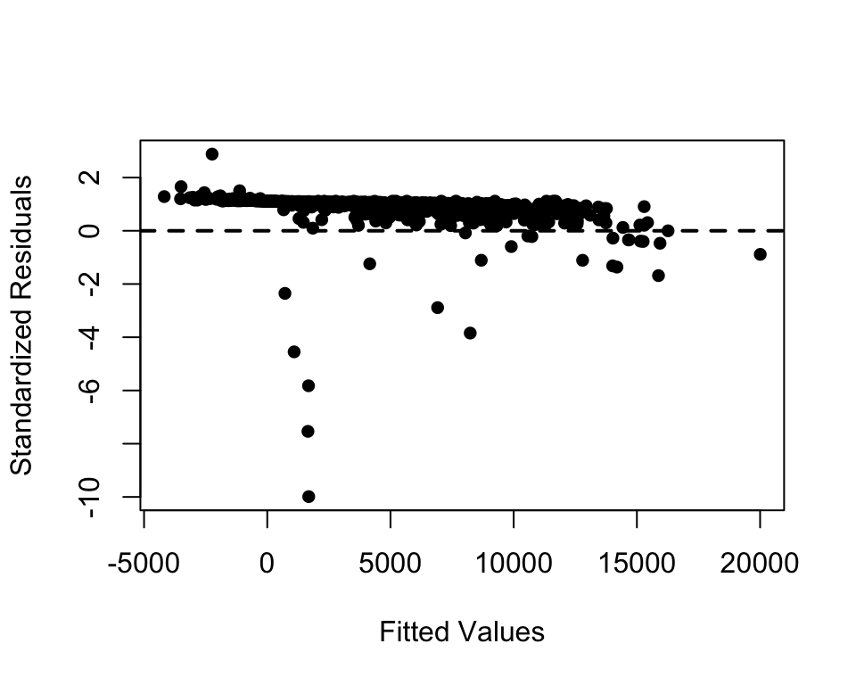

```r
plot(WLS$fitted.values, rstandard(WLS), xlab = "Fitted Values", ylab = "Standardized Residuals",
    pch = 16)
abline(h = 0, lty = 2, lwd = 2)
```

We finally have gotten statistically significant covariates and respectively significant p-values through the WLS model. Age has a statistically significant positive effect on income under WLS, having coefficient 229.07 and p-value 3.11e-13. Hours has a statistically significant negative effect on income under WLS, having coefficient -69.61 and p-value 0.00624. MEduc has a statistically significiant negative effect on income under WLS, having coefficient -336.67 and p-value 0.00688. FEduc has a statistically significant positive effect on income under WLS, having coefficient 471.23 and p-value 5.22e-11. And lastly, Sibs has a statistically significant positive effect on income under WLS with coefficient 607.76 and p-value 2.89e-07. Up until this point, we had no variables show statistical significance and because WLS reweights to account for possible heteroscedasticity, the fact that several covariates became significant under WLS may indicate that non-constant variance in the OLS model masked these relationships.

If high-income individuals in the GSS have massive variance in their reported income (some making 100k, some 500k with the same education level), OLS treats that noise as if it applies to everyone. However, WLS clears out that noise and puts less emphasis on the data points with extremely high variance (the outliers/ leverage points) and gives more emphasis to the stable/ “good” data points. The WLS model is: 1. Isolating the noise 2. Decreases standard error (through giving emphasis to stable data points) 3. P-values then drop below 0.05 due to the reasons above and we finally see which covariates are truly significant

WLS doesn’t create significance rather it just fixes a violation of Gauss-Markov assumptions that was hiding the true relationship.

### Iteratively Reweighted Least Squares Method as a function of the Age Covariate

```r
w = rep(1, n)
err = Inf
tol = 1e-10
niter = 0
maxiter = 1000

while (err > tol & niter < maxiter) {
    aux = lm(log(residuals^2) ~ log(Age), data = gss)

    err = sum(abs(w - exp(-aux$fitted.values)))/sum(w)
    w = exp(-aux$fitted.values)  # model is now aged based weights
    WLS = lm(Income ~ Age + Educ + Hours + TVHours + MEduc + FEduc +
        Sibs, data = gss, weights = w)

    residuals = WLS$residuals
    niter = niter + 1
}
summary(aux)
```

```
##
## Call:
## lm(formula = log(residuals^2) ~ log(Age), data = gss)
##
## Residuals:
##      Min       1Q   Median       3Q      Max
## -10.1868  -0.7739   0.1970   0.9735   9.6953
##
## Coefficients:
##             Estimate Std. Error t value Pr(>|t|)
## (Intercept)  22.2574     0.7599  29.289  < 2e-16 ***
## log(Age)      0.6978     0.2044   3.414 0.000671 ***
## ---
## Signif. codes:  0 '***' 0.001 '**' 0.01 '*' 0.05 '.' 0.1 ' ' 1
##
## Residual standard error: 1.977 on 813 degrees of freedom
## Multiple R-squared:  0.01414,    Adjusted R-squared:  0.01292
## F-statistic: 11.66 on 1 and 813 DF,  p-value: 0.0006708
```

```r
summary(WLS)
```

```
##
## Call:
## lm(formula = Income ~ Age + Educ + Hours + TVHours + MEduc +
##     FEduc + Sibs, data = gss, weights = w)
##
## Weighted Residuals:
##     Min      1Q  Median      3Q     Max
##  -4.477  -1.541  -1.052  -0.583 127.440
##
## Coefficients:
##             Estimate Std. Error t value Pr(>|t|)
## (Intercept)   263813     661484   0.399   0.6901
## Age             2073       6360   0.326   0.7446
## Educ           19811      35432   0.559   0.5762
## Hours          -7530       5832  -1.291   0.1970
## TVHours       -56355      40846  -1.380   0.1681
## MEduc          -2459      32197  -0.076   0.9391
## FEduc           -694      28387  -0.024   0.9805
## Sibs           59813      33614   1.779   0.0755 .
## ---
## Signif. codes:  0 '***' 0.001 '**' 0.01 '*' 0.05 '.' 0.1 ' ' 1
##
## Residual standard error: 9.297 on 807 degrees of freedom
## Multiple R-squared:  0.008883,   Adjusted R-squared:  0.0002864
## F-statistic: 1.033 on 7 and 807 DF,  p-value: 0.406
```

The summary of the aux model confirms that Age is statistically associated with the variance of residuals in the GSS data since it produces a p-value of 0.00067. The slope is also positive, 0.6978 which implies that variance increases with age, but at a relatively low rate, suggesting that income variability grows as people get older.

After applying the IRLS method using age-based weights, the resulting model yields no statistically significant covariates at the 0.05 level. The R^2 adj is at 0.0002864 which basically implies that the model explains none of the variation in income.

Thus it is very important to correctly specify the variance when applying WLS as the wrong specification can worsen the model.

## ii) Write down and interpret your estimated equation for the residual variance.

Estimated equation for the residual variance: $\log(\hat{\sigma_i^2}) = \hat{\alpha_0} + 0.6978\log(\text{Age})$ Exponentiate: $\sigma_i^2 = \exp^{\hat{\alpha_0}} * \text{Age}^{0.6978}$

```r
# From the aux in part i
intercept <- exp(22.2574)
multiplier <- gss$Age^(0.6978)

residual_variance = intercept * multiplier

new_weight = 1/(residual_variance)
```

The coefficient is positive which means that the variance of the error term increases as Age increases. Each age data point (within the 815) is put to the power of 0.6978, meaning that the variance of the income residuals increase by 0.7% (it is the magnitude multiplier).

## iii) Use the optimal weights to apply the weighted least squares method with all available quantitative covariates.

```r
WLS = lm(Income ~ Age + Educ + Hours + TVHours + MEduc + FEduc + Sibs,
    data = gss, weights = new_weight)
summary(WLS$fitted.values)
```

```
##    Min. 1st Qu.  Median    Mean 3rd Qu.    Max.
## -715463  199270  314758  324681  434852 1262554
```

```r
summary(summary(WLS)$residuals)
```

```
##       Min.    1st Qu.     Median       Mean    3rd Qu.       Max.
##  -4.477517  -1.541252  -1.052396   0.000172  -0.583248 127.442519
```

```r
summary(WLS)
```

```
##
## Call:
## lm(formula = Income ~ Age + Educ + Hours + TVHours + MEduc +
##     FEduc + Sibs, data = gss, weights = new_weight)
##
## Weighted Residuals:
##     Min      1Q  Median      3Q     Max
##  -4.478  -1.541  -1.052  -0.583 127.443
##
## Coefficients:
##             Estimate Std. Error t value Pr(>|t|)
## (Intercept) 263811.3   661484.2   0.399   0.6901
## Age           2072.6     6359.8   0.326   0.7446
## Educ         19811.2    35431.6   0.559   0.5762
## Hours        -7529.7     5831.9  -1.291   0.1970
## TVHours     -56354.8    40846.3  -1.380   0.1681
## MEduc        -2459.0    32196.6  -0.076   0.9391
## FEduc         -693.8    28386.7  -0.024   0.9805
## Sibs         59813.0    33613.9   1.779   0.0755 .
## ---
## Signif. codes:  0 '***' 0.001 '**' 0.01 '*' 0.05 '.' 0.1 ' ' 1
##
## Residual standard error: 9.297 on 807 degrees of freedom
## Multiple R-squared:  0.008883,   Adjusted R-squared:  0.0002864
## F-statistic: 1.033 on 7 and 807 DF,  p-value: 0.406
```

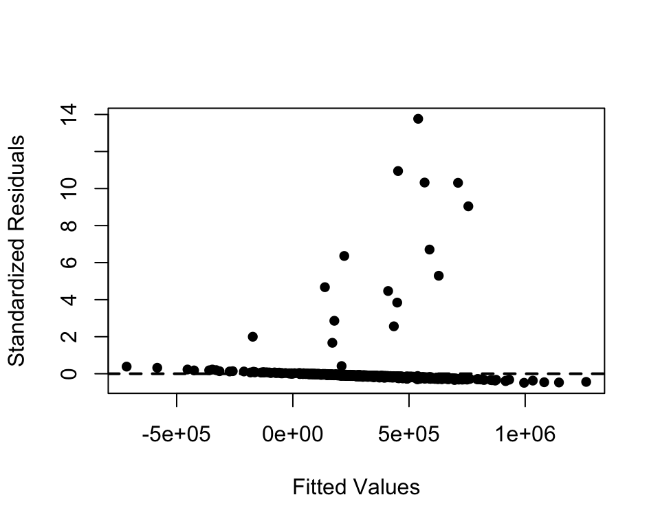

```r
plot(WLS$fitted.values, rstandard(WLS), xlab = "Fitted Values", ylab = "Standardized Residuals",
    pch = 16)
abline(h = 0, lty = 2, lwd = 2)
```

## iv) Calculate t test statistics and 95 percent CIs for the regression coefficients.

### T test statistics for the regression coefficients

```r
coef_table <- summary(WLS)$coefficients
variable_t_stats <- coef_table[, "t value"]
variable_t_stats
```

```
## (Intercept)         Age        Educ       Hours     TVHours       MEduc
##  0.39881724  0.32588788  0.55913996 -1.29112793 -1.37967842 -0.07637364
##       FEduc        Sibs
## -0.02443995  1.77941445
```

### 95 percent CIs for the regression coefficients

```r
WLS_ci <- confint(WLS, level = 0.95)
WLS_ci
```

```
##                    2.5 %     97.5 %
## (Intercept) -1034621.314 1562243.93
## Age           -10411.075   14556.22
## Educ          -49737.753   89360.20
## Hours         -18977.097    3917.73
## TVHours      -136532.284   23822.77
## MEduc         -65657.914   60739.97
## FEduc         -56414.177   55026.64
## Sibs           -6167.926  125793.93
```